# Meteoric Water Lines from GNIP data

Tobias Recke

2016-11-29

**The tutorial depends on the following packages:**

- library(dplyr)
- library(purrr)
- library(tidyr)
- library(zoo)
- library(ggplot2)

### Theoretical Backround

The hydrogen and oxygen isotopic signatures of precipitation are related on a global scale. The relationship was first observed by Harmon Craig (1961), who defined the Global Meteoric Water Line (GMWL):

$\delta$²H = 8 $\delta$¹⁸O + 10 ‰, SMOW

The GMWL is composed of weighted average annual values of precipitation data monitored at stations in the IAEA GNIP. Therefore it is actually an average of many local or regional meteoric water lines, which differ from the GMWL in slope and deuterium intercept because of varying climatic and geographic parameters (Clark & Fritz 1997).

### Data pre-processing

To calculate the LMWLs of different stations of Germany by using the [GNIP database](http://www-naweb.iaea.org/napc/ih/IHS_resources_gnip.html) some pre-processing is a must. Fortunately the whole database is already read to a tidy data frame, as described [here](http://n-dim.de/tutorial/webscraping-with-rvest.html).

So, at a first step the tibble ‘stations’ is filtered for the data frames of Germany.

```r
stG<-filter(stations, Country =='Germany')
```

Then, the map function of the package purrr is used to select the columns of interest of each data frame. Finally, the dplyr bind_rows function binds the multiple data frames into one ‘st_G_dat’.

```r
st_G_dat<-map(stG$data, select, c(1:6,11,15,17,22:23)) %>% bind_rows
```

The ‘st_G_dat’ data set contains 11 variables of different types e.g. character or integer

```r
head(st_G_dat)
```

```
## # A tibble: 6 x 11
##           `Name of site` Country `WMO Code` Latitude Longitude Altitude
##                    <chr>   <chr>      <int>    <dbl>     <dbl>    <int>
## 1 GARMISCH-PARTENKIRCHEN      DE    1096300  47.4828   11.0622      719
## 2 GARMISCH-PARTENKIRCHEN      DE    1096300  47.4828   11.0622      719
## 3 GARMISCH-PARTENKIRCHEN      DE    1096300  47.4828   11.0622      719
## 4 GARMISCH-PARTENKIRCHEN      DE    1096300  47.4828   11.0622      719
## 5 GARMISCH-PARTENKIRCHEN      DE    1096300  47.4828   11.0622      719
## 6 GARMISCH-PARTENKIRCHEN      DE    1096300  47.4828   11.0622      719
## # ... with 5 more variables: Date <chr>, O18 <dbl>, H2 <dbl>,
## #   Precipitation <dbl>, `Air Temperature` <dbl>
```

For further analyses the time variable needs to be converted from text to a time instance like yearmon from the package zoo. Then, new variables like month and year are easily added by the mutate function.

```r
st_G_dat<-st_G_dat %>% mutate(Date = as.yearmon(Date)) %>%
mutate(Jahr = as.numeric(format(Date, "%Y"))) %>%
mutate(Monat = as.numeric(format(Date, "%m")) )
```

To avoid error messages the white spaces in the column names are replaced with dots. This is done with R’s built-in make.names function.

```r
names(st_G_dat)<-make.names(names(st_G_dat))
```

Now, a first look at the $\delta$¹⁸O time series reveals different record lengths and some more or less huge data gaps.

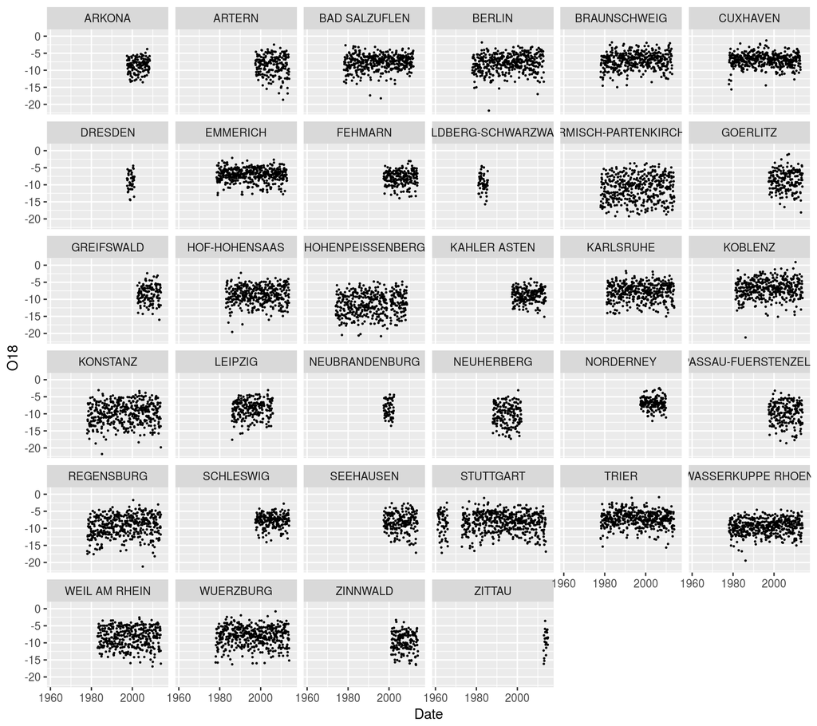

```r
ggplot(st_G_dat %>% select(c(1), Date, O18) , aes(Date, O18))+
  geom_point(size=.25)+
  facet_wrap(~ Name.of.site)
```

To analyze the isotopic signatures of the German stations, it is obvious to select those stations that contain a lot of samples in a common time window such as the 13 years lasting period between 1997 and 2009. To achieve this selection a few more steps have to be taken.

At first, the data set needs to be filtered for a specific time period.

```r
fdat<-st_G_dat %>% group_by(Name.of.site) %>% filter(., Jahr %in% seq(1997,2009 ,1))
```

Next up, is to create a data set that additionally contains a variable of the period length of each station.

```r
dum<-fdat %>% group_by(Name.of.site) %>% distinct(Jahr) %>% mutate(Jahr, n = n())
```

In a further step the station names of the previously created data set, that match the time period of 13 years, are extracted and saved as vector.

```r
stat<-summarise(dum, LJ=length(Jahr)) %>% filter(LJ==13) %>%
  select(Name.of.site) %>% collect %>% .[["Name.of.site"]]
```

At last, the fdat data set is filtered by the ‘stat’ vector.

```r
t4<-filter(fdat, Name.of.site %in% stat)
```

The pre-processed data can now be examined with the ggplot function. Here is an example of the extracted $\delta$¹⁸O time series:

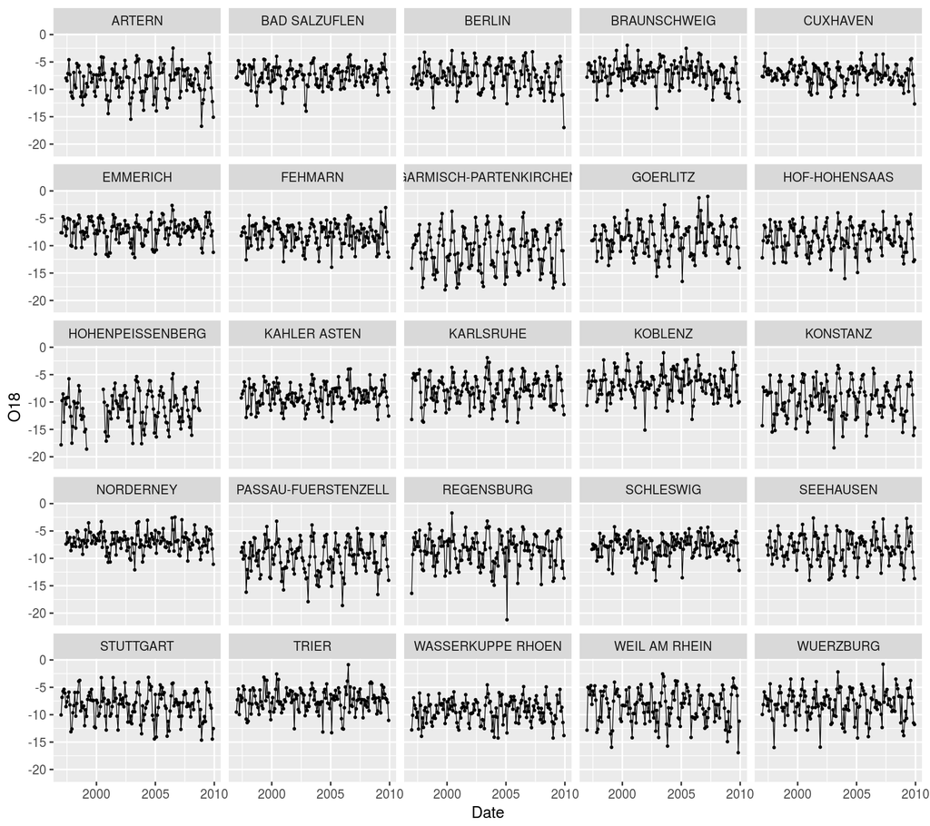

```r
ggplot(group_by(t4, Name.of.site) %>% bind_rows(),
       aes(x=Date, y=O18))+
  geom_point( size=.5)+
  geom_line(size=.25)+
  facet_wrap(~ Name.of.site)
```

### Regression Analyses

With the pre-processed data set the linear relationship of $\delta$²H and $\delta$¹⁸O of each station can now be calculated, as shown in the next example. The example was inspired by Stumpp et al. (2014). The source code mainly originates from [Rstudio blog](https://blog.rstudio.org/2016/02/02/tidyr-0-4-0/).

```r
aswj<-t4 %>%
  group_by(Name.of.site) %>%
  nest() %>%  mutate(waterline = purrr::map(data, ~ lm(H2 ~ O18, data = . , na.action=na.omit)))
```

Furthermore with the powerful broom package one can shortly convert model coefficients or summaries, whereby the output will be a data frame or a one-row data frame, respectively.

```r
wlcoeff<-aswj %>% unnest(waterline %>% purrr::map(broom::tidy))
wlsy<-aswj %>% unnest(waterline %>% purrr::map(broom::glance))
```

Now that the regression analyses are done, let’s plot the slopes and the R²s on a German map, by using the world database of the package maps as well as ggplot2.

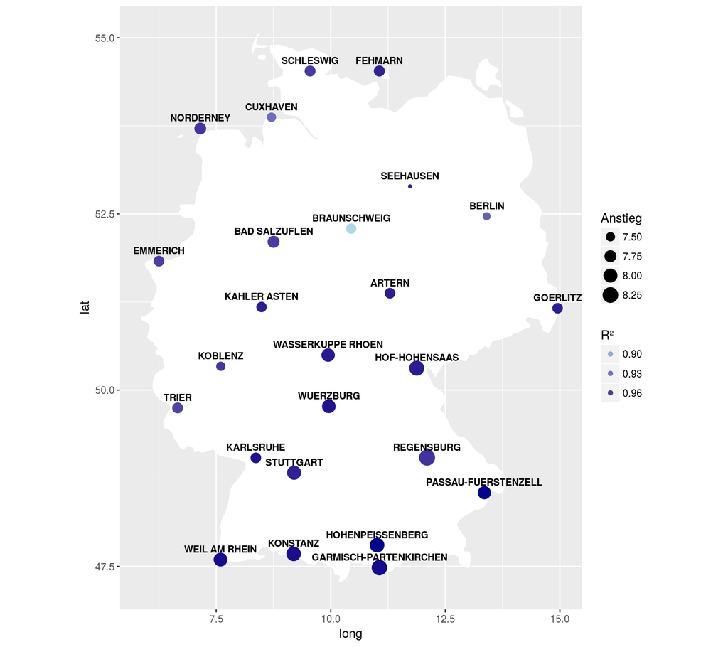

```r
lla<-aswj %>% unnest(data) %>% select(Latitude, Longitude, Altitude) %>% unique()


ger<-map_data('world', 'Germany')

layout(matrix(c(1), 1))
par(mar = c(4, 4, 4, 2) + 0.1)
ggplot() +  geom_polygon(data=ger, aes(x=long, y=lat, group=group), fill='white')+
  geom_point(data=lla, aes(x=Longitude, y=Latitude, size=wlcoeff$estimate[wlcoeff$term=='O18'],
                           color=wlsy$r.squared), show.legend = T)+
  scale_size('Anstieg')+
  scale_colour_gradient("R²", low = "lightblue", high = "darkblue")+
  geom_text(data=lla, size = 3, colour='black', fontface ='bold',
            aes(x=Longitude, y=Latitude+.15, label = aswj$Name.of.site))+
  coord_equal(ratio=2/1.3)+
  guides(color = guide_legend(order=2),
         size = guide_legend(order=1))
```

The plot reveals some dependencies between the isotopic signatures and the parameters latitude and elevation. For example, the continental stations at higher elevations have steeper slopes than the coastal ones. Indeed these effects are subject to temperature dependent thermodynamic fractionations (e.g. due to humidity) (Clark & Fritz 1997; Stumpp et al. 2014).

### Resources:

Stumpp, C., Klaus, J., & Stichler, W. (2014). Analysis of long-term stable isotopic composition in German precipitation. Journal of Hydrology, 517, 351-361.

Clark, I. D., & Fritz, P. (1997). Environmental isotopes in hydrogeology. CRC press.